# Validating Measures of Prejudice and Disgust

In this project I am interested in how a respondent’s behavior changes when given different information about the individual. I have three hypothetical individuals, 1) an ingroup member 2) a violent individual 3) and an infected individual.

```r
rm(list = ls())

setwd("C:/Users/cayde/OneDrive/Data Science/R Projects/Data Visualization") #Home

library(dplyr)
library(tidyr)
library(ggplot2)

behavior_raw <- read.csv("Disgust Validation Project_December 2, 2022_12.11.csv")
```

This is a small pilot data set that I ran on my undergraduate students. I use their Survey ID to get the valid responses and filter accordingly.

```r
valid_responses <- c("3489", "5138", "2602", "9313", "6019", "1169",
                     "5971", "8276", "6284", "1466", "2194", "7636", "2208",
                     "1533", "9658")

behavior_raw <- filter(behavior_raw, SURVEY.ID %in% valid_responses)
```

Next I identify the relevant variables. I do this by creating character vectors so I can subset my data. The first vector I create is called ‘covariates’ and is simply information about the target individual. More importantly is the behavior questions, which I put in the “ingroup” varnames.

```r
#Cleaning the data and assigning names to be used for subsetting
#################################################################

covariate_names <- c("ResponseId", "Name1", "Name2", "Name3", "Age1",
                     "Num_Siblings1", "Age2", "Num_Siblings2", "Age3",
                     "Num_Siblings3", "Hobbies1", "Hobbies2", "Hobbies3",
                     "Name", "Age", "Num_Siblings", "Hobbies")

ingroup_varnames <- c("feeling_1", "toilet_seat", "personal", "party", "hug",
                      "food_utensils", "drinking", "roommate", "elevator", "borrow",
                      "mail", "concert", "open.carry", "background", "overtime",
                      "holiday", "transaction", "road", "sheets", "food_prep",
                      "clothes", "gas", "neighbor")
```

Because I asked the same set of questions for all three individuals, Qualtrics labels repeat questions with a .1 or .2. I take advantage of this pattern and use the addendum to identify the questions asked towards the violent and infected individuals.

```r
infected_addendum <- ".1"
violent_addendum <- ".2"

infected_varnames <- sapply(ingroup_varnames, function(x){paste0(x, infected_addendum)})
violent_varnames <- sapply(ingroup_varnames, function(x){paste0(x, violent_addendum)})
```

Here I remove the metadata by subsetting the data on my variables of interest.

```r
#Removing Rows and Columns
behavior <- behavior_raw[-c(1,2),]
behavior <- behavior[,c(ingroup_varnames, infected_varnames, violent_varnames, covariate_names)]
```

Standard data transformation in which I convert the string variable to a numeric for data analysis.

```r
# Convert the Likert scale to numeric
#####################################

first_var<- which(colnames(behavior) == "toilet_seat")
last_var <- which(colnames(behavior) == "neighbor.2")

for(column in first_var:last_var){
  if(grepl("feeling", names(behavior[column]))){next}
  behavior[, column] <- recode(behavior[, column], "Very comfortable" = 1,
                               "Comfortable" = 2,
                               "Neutral" = 3,
                               "Uncomfortable" = 4,
                               "Very uncomfortable" = 5)
}
```

Using my previously created character vectors, I subset the data by the type of individual. Since there are three individuals (ingroup, infected, violent) I have three new data sets. Once in their new dataframe, I remove the .1 and .2 in order to have the variable names match.

```r
# Creating a score for each battery
###################################

#subsetting data by treatment


ingroup <- behavior[,c(ingroup_varnames, covariate_names)]
infected <- behavior[,c(infected_varnames, covariate_names)]
violent <- behavior[,c(violent_varnames, covariate_names)]

#renaming the question names to avoid the duplicate naming conventions
names(infected) <- gsub(pattern = infected_addendum, replacement = "", x = names(infected), fixed = TRUE)
names(violent) <- gsub(pattern = violent_addendum, replacement = "", x = names(violent), fixed = TRUE)
```

I am going to aggregate the data in the three new data frames and create new data set. To keep track of where the data comes from, I created a treatment variable that corresponds to the conidtion of the individual.

```r
#Creating a treatment variable
ingroup$treatment <- "ingroup"
infected$treatment <- "infected"
violent$treatment <- "violent"
```

The behavioral questions I have are based on two factors: disgust and general. I create character vectors to partition the questions based on these two dimensions.

```r
#Creating total prejudice scores based on type

disgust_varnames <- c("toilet_seat", "personal", "party", "hug", "food_utensils",
                      "drinking", "roommate", "elevator", "sheets", "food_prep",
                      "clothes")

general_varnames <- c("borrow", "mail", "concert", "open.carry", "background",
                      "overtime", "holiday", "transaction", "road", "gas", "neighbor")
```

Next, I simply add up the responses to the behavioral questions to get an index. I do these for all of my 3 subsets. I then standardize the data.

```r
ingroup$disgust <- rowSums(ingroup[,disgust_varnames])
ingroup$general <- rowSums(ingroup[,general_varnames])

infected$disgust <- rowSums(infected[,disgust_varnames])
infected$general <- rowSums(infected[,general_varnames])

violent$disgust <- rowSums(violent[,disgust_varnames])
violent$general <- rowSums(violent[,general_varnames])

# Creating standardized scales of scores

ingroup$disgust_s <- (ingroup$disgust - length(disgust_varnames))/(length(disgust_varnames)*5 - length(disgust_varnames))
ingroup$general_s <- (ingroup$general - length(general_varnames))/(length(general_varnames)*5 - length(general_varnames))

infected$disgust_s <- (infected$disgust - length(disgust_varnames))/(length(disgust_varnames)*5 - length(disgust_varnames))
infected$general_s <- (infected$general - length(general_varnames))/(length(general_varnames)*5 - length(general_varnames))

violent$disgust_s <- (violent$disgust - length(disgust_varnames))/(length(disgust_varnames)*5 - length(disgust_varnames))
violent$general_s <- (violent$general - length(general_varnames))/(length(general_varnames)*5 - length(general_varnames))
```

I rename the original data set to ‘wide’ because the data is in a wide format. I then merge the 3 data sets with the transformed data. Because I created a treatment variable, I know which data belongs to which individual when it is in the merged data set. I also create a new ‘total’ index which is a combination of the disgust and general behaviors.

```r
#Recombining the data to have it in 'long' format

behavior_wide <- behavior #renaming the original data set to preserve data

names(infected)[!names(infected) == names(ingroup)]
```

```
character(0)
```

```r
names(ingroup)[!names(infected) == names(ingroup)]
```

```
character(0)
```

```r
behavior <- rbind(ingroup, infected, violent)

# Adding a category of total prejudice
behavior$total <- behavior$disgust + behavior$general
behavior$total_s <- (behavior$total - length(c(disgust_varnames, general_varnames)))/(length(c(disgust_varnames, general_varnames))*5 - length(c(disgust_varnames, general_varnames)))


#Cleaning up the environment
rm(list = ls()[!ls() %in% c("behavior", "disgust_varnames", "disgust_varnames_R", "general_varnames_R", "general_varnames", "ingroup", "infected", "violent")])
behavior <- behavior[,c("ResponseId", "feeling_1", "total", "total_s", "disgust", "disgust_s", "general", "general_s", "treatment", disgust_varnames, general_varnames)]
```

I am principally interested in how the condition of the target individual affects the respondent’s behavior. I expect that disgust-related behaviors are going to change when the individual is infected, and that general-related behaviors are going to change when the target is violent.To see if this is the case, I create graphs that seperate the behavioral responses by individual type.

The first graph demonstrates how behavior changes based on the targets’ condition. Higher values indicate more negative attitudes and avoident behaviors.

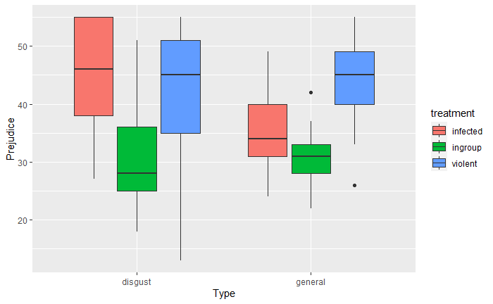

```r
behavior_long <- gather(behavior, "type", "outcome", c(disgust, general)) #converting to long form for the graph

ggplot(behavior_long, mapping = aes(x = type, y = outcome, fill = treatment)) +
  geom_boxplot() +
  ylab("Prejudice") +
  xlab("Type")
```

```r
NA
NA
NA
```

Looking at the graph, we can see that respondents have much greater disgust prejudice towards the infected individual than the ingroup. However, the respondents are equally ‘disgusted’ by the violent and infected individual. This suggests that the disgust measurements are picking up on something else. The general prejudice measure fares better. Respondents are much more prejudiced against a violent individual than both the infected and ingroup individual.

To see what is causing this, I disaggregate the responses by question type. The goal of this project is to identify questions that seperate disgust-related prejudice from general prejudice.

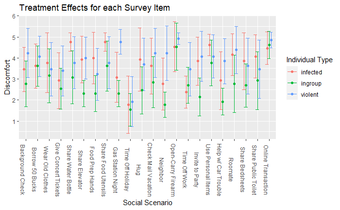

```r
#################
# Data Visualization
################

##############################
# Plotting Means for Questions

# Original

question_means <- behavior %>%
  group_by(treatment) %>%
  summarize_at(vars(c(disgust_varnames, general_varnames)), list(avg = mean))

question_sds <- behavior %>%
  group_by(treatment) %>%
  summarize_at(vars(c(disgust_varnames, general_varnames)), list(std = sd))

question_means_long <- gather(question_means, "question", "average", names(question_means)[-1])
question_sds_long <- gather(question_sds, "question", "standard_deviation", names(question_sds)[-1])

question_stats <- cbind(question_means_long, question_sds_long[,3])

pd <- position_dodge(width = 0.5)

x_labels <- c("Background Check", "Borrow 50 Bucks", "Wear Old Clothes",
              "Give Concert Tickets", "Share Water Bottle", "Share Elevator",
              "Food Prep Hands", "Share Food Utensils", "Gas Station Night",
              "Time Off Holiday", "Hug", "Check Mail Vacation", "Neighbor",
              "Open-Carry Firearm", "Time Off Work", "Invite to Party",
              "Use Personal Items", "Help w/ Car Trouble", "Roomate",
              "Share Bedsheets", "Share Public Toilet", "Online Transaction")

ggplot(question_stats, aes(x = question, y = average, color = treatment)) +
  geom_errorbar(aes(ymin = average - standard_deviation, ymax = average + standard_deviation), position = pd) +
  geom_point(position = pd) +
  theme(axis.text.x = element_text(angle = -90)) +
  scale_x_discrete(labels = x_labels) +
  ylab("Discomfort") +
  xlab("Social Scenario") +
  ggtitle("Treatment Effects for each Survey Item") +
  guides(color = guide_legend("Individual Type"))
```

Here we can see how the questions are performing. Certain behaviors like sharing a water bottle or food utensils are greatly impacted by whether the target individual is infected, but not violent. Conversely other behavior like meeting someone at a gas station late at night or being neighbors is greatly impacted by whether the individual is violent but not whether they are infected. Certain items such as hugging, invitation to parties, and roommates, are equally repulsive for violent and infected individuals. I had hypothesized that these behaviors were’ disgust-related’ behaviors.

To refine my battery, I take out the items that show little separation between infected and violent individuals. A couple items, such has sharing bed sheets, showed little separation, but I have strong theoretical reasons to believe that these items ‘should’ be showing separation. I thus keep them in. I now have a condensed and refined battery.

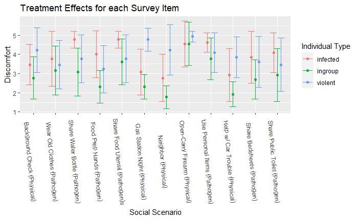

```r
# Creating a vector of covariate labels for a revised battery

disgust_varnames_R <- c("toilet_seat", "personal", "food_utensils",
                        "drinking", "sheets", "food_prep",
                        "clothes")

general_varnames_R <- c("open.carry", "background",
                        "road", "gas", "neighbor")


question_means_R <- behavior %>%
  group_by(treatment) %>%
  summarize_at(vars(c(disgust_varnames_R, general_varnames_R)), list(avg = mean))

question_sds_R <- behavior %>%
  group_by(treatment) %>%
  summarize_at(vars(c(disgust_varnames_R, general_varnames_R)), list(std = sd))

question_means_long_R <- gather(question_means_R, "question", "average", names(question_means_R)[-1])
question_sds_long_R <- gather(question_sds_R, "question", "standard_deviation", names(question_sds_R)[-1])

question_stats_R <- cbind(question_means_long_R, question_sds_long_R[,3])

pd <- position_dodge(width = 0.5)

x_labels_R <- c("Background Check (Physical)", "Wear Old Clothes (Pathogen)", "Share Water Bottle (Pathogen)",
              "Food Prep Hands (Pathogen)", "Share Food Utensil (Pathogen)s", "Gas Station Night (Physical)",
              "Neighbor (Physical)", "Open-Carry Firearm (Physical)", "Use Personal Items (Pathogen)", "Help w/ Car Trouble (Physical)",
              "Share Bedsheets (Pathogen)", "Share Public Toilet (Pathogen)")

ggplot(question_stats_R, aes(x = question, y = average, color = treatment)) +
  geom_errorbar(aes(ymin = average - standard_deviation, ymax = average + standard_deviation), position = pd) +
  geom_point(position = pd) +
  theme(axis.text.x = element_text(angle = -85)) +
  scale_x_discrete(labels = x_labels_R) +
  ylab("Discomfort") +
  xlab("Social Scenario") +
  ggtitle("Treatment Effects for each Survey Item") +
  guides(color = guide_legend("Individual Type"))
```

With the revised and relabeled graph we can see much better results. The variables labeled “Physical” should result in more prejudice against violent individuals. This is the case for every single variable. The variables labeled “Pathogen” should result in more prejudice against infected individuals. Once again this is true of every variable.

Now that we have a more defined battery, let’s look at the overall treatment effects.

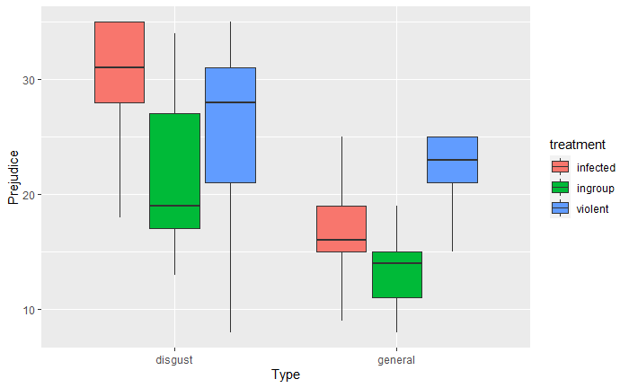

```r
####################
# Treatment Effects

behavior_R <- behavior[, c("ResponseId", "treatment", "feeling_1", "total", disgust_varnames_R, general_varnames_R)]

behavior_R$disgust <- rowSums(behavior_R[,disgust_varnames_R])
behavior_R$general <- rowSums(behavior_R[,general_varnames_R])

behavior_long_R <- gather(behavior_R, "type", "outcome", c(disgust, general))

ggplot(behavior_long_R, mapping = aes(x = type, y = outcome, fill = treatment)) +
  geom_boxplot() +
  ylab("Prejudice") +
  xlab("Type")
```

The last step of the process is to show that these behaviors that I have measured correlate to more traditional measures of prejudice. To show this I I use the combined index that I created earlier and plot it against the feeling thermometer ratings that I obtained for the individual. Feeling thermometers are a classic measurement in social science that measures how ‘cold’ or ‘warm’ you feel towards an individual or group of people.

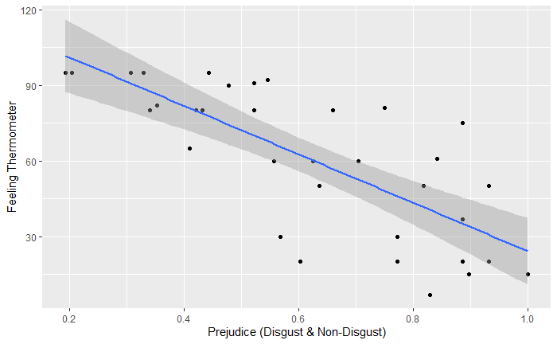

```r
# Correlations

behavior_clean_R <- filter(behavior, feeling_1 >= 0)
behavior_clean_R$feeling_1 <- as.numeric(behavior_clean_R$feeling_1)

general_model_R <- lm(feeling_1 ~ total, data = behavior_clean_R)

ggplot(behavior_clean_R, mapping = aes(x = total_s, y = feeling_1)) +
  geom_point() +
  geom_smooth(method = 'lm') +
  ylab("Feeling Thermometer") +
  xlab("Prejudice (Disgust & Non-Disgust)")
```

The graph shows a decently strong correlation between the two measures, indicating that the attitudes and behaviors I measured are in fact picking up on prejudice.

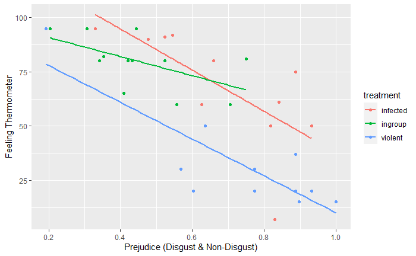

```r
ggplot(behavior_clean_R, mapping = aes(x = total_s, y = feeling_1, color = treatment)) +
  geom_point() +
  geom_smooth(method = 'lm', se = FALSE) +
  ylab("Feeling Thermometer") +
  xlab("Prejudice (Disgust & Non-Disgust)")
```

```r
NA
```

In conclusion it is possible to disentangle prejudicial attitudes towards individuals that are based on disgsut and those that are based on disgust. Visualizing the data helped me refine my measurements and more accurately disentangle these concepts.